# Homework5Key_SPSS_Output

[output not shown]

Log  
Log - Log - December 1, 2018

* Encoding: UTF-8.  
* ============================================.  
* N736 Homework 5: Analysis of Covariance (ANCOVA)  
* and Moderation (interaction effects)  
*  
* by Melinda Higgins, PhD  
* dated December 1, 2018  
* ============================================.  
* ============================================.  
* For this Homework 5 we will be working with the HELP dataset  
* load helpmkh.sav  
* ============================================.  
* ============================================.  
* We will be working with these variables from the HELP dataset  
* mcs, age and homeless  
*  
* Run descriptive statistics on these variables  
* ============================================.  
FREQUENCIES VARIABLES=mcs age homeless  
/NTILES=4  
/STATISTICS=STDDEV MINIMUM MAXIMUM MEAN  
/HISTOGRAM  
/ORDER=ANALYSIS.

Frequencies  
Frequencies - Active Dataset - December 1, 2018

[DataSet1] C:\MyGithub\N736Fall2017_Homework5Key\helpmkh.sav

Frequencies  
Frequencies - Statistics - December 1, 2018

StatisticsStatistics, table, 1 levels of column headers and 2 levels of row headers, table with 5 columns and 11 rows

|  |  | mcs SF36 Mental Composite Score - Baseline | age Age at baseline (in years) | homeless One or more nights on the street or shelter in past 6 months |
| --- | --- | --- | --- | --- |
| N | Valid | 453 | 453 | 453 |
|  | Missing | 0 | 0 | 0 |
| Mean |  | 31.676678300000000 | 35.65 | .46 |
| Std. Deviation |  | 12.839337310000000 | 7.710 | .499 |
| Minimum |  | 6.76292324100000 | 19 | 0 |
| Maximum |  | 62.17550278000000 | 60 | 1 |
| Percentiles | 25 | 21.672114370000000 | 30.00 | .00 |
|  | 50 | 28.602416990000002 | 35.00 | .00 |
|  | 75 | 40.975919720000000 | 40.50 | 1.00 |

Frequency Table  
Frequency Table - mcs SF36 Mental Composite Score - Baseline - December 1, 2018

mcs SF36 Mental Composite Score - Baselinemcs SF36 Mental Composite Score - Baseline, table, 1 levels of column headers and 2 levels of row headers, table with 6 columns and 456 rows

|  |  | Frequency | Percent | Valid Percent | Cumulative Percent |
| --- | --- | --- | --- | --- | --- |
| Valid | 6.76292324100000 | 1 | .2 | .2 | .2 |
|  | 7.03530740700000 | 1 | .2 | .2 | .4 |
|  | 7.22659730900000 | 1 | .2 | .2 | .7 |
|  | 7.93822145500000 | 1 | .2 | .2 | .9 |
|  | 9.16053009000000 | 1 | .2 | .2 | 1.1 |
|  | 9.40637683900000 | 1 | .2 | .2 | 1.3 |
|  | 9.73255920400000 | 1 | .2 | .2 | 1.5 |
|  | 10.56476212000000 | 1 | .2 | .2 | 1.8 |
|  | 11.49986458000000 | 1 | .2 | .2 | 2.0 |
|  | 11.81906986000000 | 1 | .2 | .2 | 2.2 |
|  | 12.20421886000000 | 1 | .2 | .2 | 2.4 |
|  | 12.32359409000000 | 1 | .2 | .2 | 2.6 |
|  | 12.43288708000000 | 1 | .2 | .2 | 2.9 |
|  | 13.13466263000000 | 1 | .2 | .2 | 3.1 |
|  | 13.31266880000000 | 1 | .2 | .2 | 3.3 |
|  | 13.38220501000000 | 1 | .2 | .2 | 3.5 |
|  | 13.41256332000000 | 1 | .2 | .2 | 3.8 |
|  | 13.85299587000000 | 1 | .2 | .2 | 4.0 |
|  | 13.96873760000000 | 1 | .2 | .2 | 4.2 |
|  | 14.10875893000000 | 1 | .2 | .2 | 4.4 |
|  | 14.35888100000000 | 1 | .2 | .2 | 4.6 |
|  | 14.41519737000000 | 1 | .2 | .2 | 4.9 |
|  | 14.48062611000000 | 1 | .2 | .2 | 5.1 |
|  | 14.89169693000000 | 1 | .2 | .2 | 5.3 |
|  | 14.91392517000000 | 1 | .2 | .2 | 5.5 |
|  | 14.91930962000000 | 1 | .2 | .2 | 5.7 |
|  | 15.07886696000000 | 1 | .2 | .2 | 6.0 |
|  | 15.10149384000000 | 1 | .2 | .2 | 6.2 |
|  | 15.19647694000000 | 1 | .2 | .2 | 6.4 |
|  | 15.26826382000000 | 1 | .2 | .2 | 6.6 |

[output cut: 425 more lines]

Frequency Table  
Frequency Table - age Age at baseline (in years) - December 1, 2018

age Age at baseline (in years)age Age at baseline (in years), table, 1 levels of column headers and 2 levels of row headers, table with 6 columns and 45 rows

|  |  | Frequency | Percent | Valid Percent | Cumulative Percent |
| --- | --- | --- | --- | --- | --- |
| Valid | 19 | 1 | .2 | .2 | .2 |
|  | 20 | 2 | .4 | .4 | .7 |
|  | 21 | 3 | .7 | .7 | 1.3 |
|  | 22 | 8 | 1.8 | 1.8 | 3.1 |
|  | 23 | 5 | 1.1 | 1.1 | 4.2 |
|  | 24 | 8 | 1.8 | 1.8 | 6.0 |
|  | 25 | 7 | 1.5 | 1.5 | 7.5 |
|  | 26 | 13 | 2.9 | 2.9 | 10.4 |
|  | 27 | 18 | 4.0 | 4.0 | 14.3 |
|  | 28 | 15 | 3.3 | 3.3 | 17.7 |
|  | 29 | 18 | 4.0 | 4.0 | 21.6 |
|  | 30 | 18 | 4.0 | 4.0 | 25.6 |
|  | 31 | 20 | 4.4 | 4.4 | 30.0 |
|  | 32 | 28 | 6.2 | 6.2 | 36.2 |
|  | 33 | 35 | 7.7 | 7.7 | 43.9 |
|  | 34 | 18 | 4.0 | 4.0 | 47.9 |
|  | 35 | 25 | 5.5 | 5.5 | 53.4 |
|  | 36 | 23 | 5.1 | 5.1 | 58.5 |
|  | 37 | 20 | 4.4 | 4.4 | 62.9 |
|  | 38 | 18 | 4.0 | 4.0 | 66.9 |
|  | 39 | 27 | 6.0 | 6.0 | 72.8 |
|  | 40 | 10 | 2.2 | 2.2 | 75.1 |
|  | 41 | 20 | 4.4 | 4.4 | 79.5 |
|  | 42 | 10 | 2.2 | 2.2 | 81.7 |
|  | 43 | 13 | 2.9 | 2.9 | 84.5 |
|  | 44 | 7 | 1.5 | 1.5 | 86.1 |
|  | 45 | 13 | 2.9 | 2.9 | 89.0 |
|  | 46 | 5 | 1.1 | 1.1 | 90.1 |
|  | 47 | 14 | 3.1 | 3.1 | 93.2 |
|  | 48 | 5 | 1.1 | 1.1 | 94.3 |
|  | 49 | 8 | 1.8 | 1.8 | 96.0 |
|  | 50 | 2 | .4 | .4 | 96.5 |
|  | 51 | 1 | .2 | .2 | 96.7 |
|  | 52 | 1 | .2 | .2 | 96.9 |
|  | 53 | 3 | .7 | .7 | 97.6 |
|  | 54 | 1 | .2 | .2 | 97.8 |
|  | 55 | 2 | .4 | .4 | 98.2 |
|  | 56 | 1 | .2 | .2 | 98.5 |
|  | 57 | 2 | .4 | .4 | 98.9 |
|  | 58 | 2 | .4 | .4 | 99.3 |
|  | 59 | 2 | .4 | .4 | 99.8 |
|  | 60 | 1 | .2 | .2 | 100.0 |
|  | Total | 453 | 100.0 | 100.0 |  |

homeless One or more nights on the street or shelter in past 6 monthshomeless One or more nights on the street or shelter in past 6 months, table, 1 levels of column headers and 2 levels of row headers, table with 6 columns and 5 rows

|  |  | Frequency | Percent | Valid Percent | Cumulative Percent |
| --- | --- | --- | --- | --- | --- |
| Valid | 0 no | 244 | 53.9 | 53.9 | 53.9 |
|  | 1 yes | 209 | 46.1 | 46.1 | 100.0 |
|  | Total | 453 | 100.0 | 100.0 |  |

Histogram  
Histogram - SF36 Mental Composite Score - Baseline - December 1, 2018

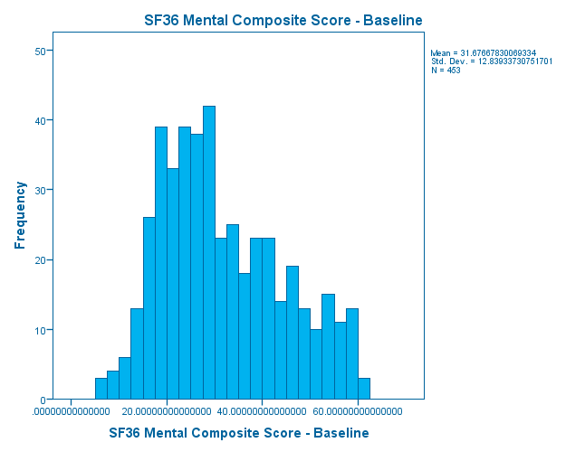

Histogram  
Histogram - Age at baseline (in years) - December 1, 2018

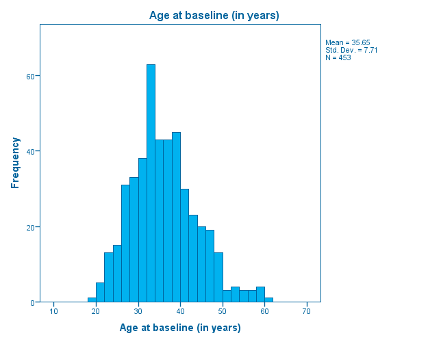

Histogram  
Histogram - One or more nights on the street or shelter in past 6 months - December 1, 2018

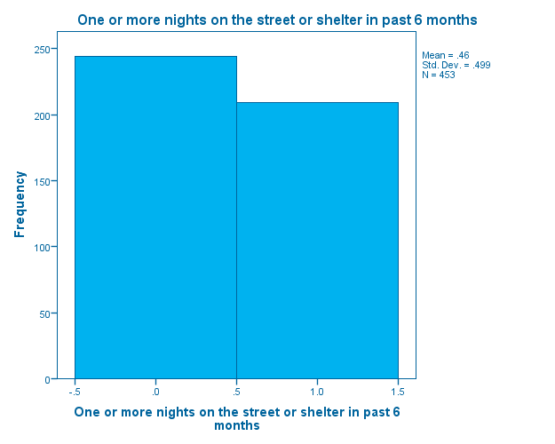

Log  
Log - Log - December 1, 2018

* ============================================.  
* Let's also look at the correlation matrix  
* ============================================.  
CORRELATIONS  
/VARIABLES=mcs age homeless  
/PRINT=TWOTAIL NOSIG  
/MISSING=PAIRWISE.

Correlations  
Correlations - Correlations - December 1, 2018

CorrelationsCorrelations, table, 1 levels of column headers and 2 levels of row headers, table with 5 columns and 11 rows

|  |  | mcs SF36 Mental Composite Score - Baseline | age Age at baseline (in years) | homeless One or more nights on the street or shelter in past 6 months |
| --- | --- | --- | --- | --- |
| mcs SF36 Mental Composite Score - Baseline | Pearson Correlation | 1 | .045 | -.068 |
|  | Sig. (2-tailed) |  | .343 | .147 |
|  | N | 453 | 453 | 453 |
| age Age at baseline (in years) | Pearson Correlation | .045 | 1 | .086 |
|  | Sig. (2-tailed) | .343 |  | .068 |
|  | N | 453 | 453 | 453 |
| homeless One or more nights on the street or shelter in past 6 months | Pearson Correlation | -.068 | .086 | 1 |
|  | Sig. (2-tailed) | .147 | .068 |  |
|  | N | 453 | 453 | 453 |

Log  
Log - Log - December 1, 2018

NONPAR CORR  
/VARIABLES=mcs age homeless  
/PRINT=SPEARMAN TWOTAIL NOSIG  
/MISSING=PAIRWISE.

Nonparametric Correlations  
Nonparametric Correlations - Correlations - December 1, 2018

CorrelationsCorrelations, table, 1 levels of column headers and 3 levels of row headers, table with 6 columns and 11 rows

|  |  |  | mcs SF36 Mental Composite Score - Baseline | age Age at baseline (in years) | homeless One or more nights on the street or shelter in past 6 months |
| --- | --- | --- | --- | --- | --- |
| Spearman's rho | mcs SF36 Mental Composite Score - Baseline | Correlation Coefficient | 1.000 | .029 | -.063 |
|  |  | Sig. (2-tailed) | . | .541 | .181 |
|  |  | N | 453 | 453 | 453 |
|  | age Age at baseline (in years) | Correlation Coefficient | .029 | 1.000 | .083 |
|  |  | Sig. (2-tailed) | .541 | . | .077 |
|  |  | N | 453 | 453 | 453 |
|  | homeless One or more nights on the street or shelter in past 6 months | Correlation Coefficient | -.063 | .083 | 1.000 |
|  |  | Sig. (2-tailed) | .181 | .077 | . |
|  |  | N | 453 | 453 | 453 |

Log  
Log - Log - December 1, 2018

* ============================================.  
* We will also be exploring the affect of the contrast comparison  
* tests run for homeless and the default handling of 0,1 coding  
* so, let's also code a variable "nothomeless" which is the reverse coding  
* of "homeless".  
* ============================================.  
compute nothomeless = homeless=0.  
compute age_x_homeless = age * homeless.  
compute age_x_nothomeless = age * nothomeless.  
execute.  
* ============================================.  
* We can use the Blocks or Step Approach of SPSS  
* to first get the  
* model1 for mcs = homeless  
* then to get  
* model2 for mcs = homeless + age  
* and finally to get  
* model3 for mcs = homeless + age + age_x_homeless  
* which tests the interaction term - homogenity of slopes test  
* ============================================.  
* ============================================.  
REGRESSION  
/DESCRIPTIVES MEAN STDDEV CORR SIG N  
/MISSING LISTWISE  
/STATISTICS COEFF OUTS CI(95) R ANOVA COLLIN TOL CHANGE ZPP  
/CRITERIA=PIN(.05) POUT(.10)  
/NOORIGIN  
/DEPENDENT mcs  
/METHOD=ENTER homeless  
/METHOD=ENTER age  
/METHOD=ENTER age_x_homeless  
/RESIDUALS HISTOGRAM(ZRESID) NORMPROB(ZRESID).

Regression  
Regression - Descriptive Statistics - December 1, 2018

Descriptive StatisticsDescriptive Statistics, table, 1 levels of column headers and 1 levels of row headers, table with 4 columns and 6 rows

|  | Mean | Std. Deviation | N |
| --- | --- | --- | --- |
| mcs SF36 Mental Composite Score - Baseline | 31.676678300000000 | 12.839337310000000 | 453 |
| homeless One or more nights on the street or shelter in past 6 months | .46 | .499 | 453 |
| age Age at baseline (in years) | 35.65 | 7.710 | 453 |
| age_x_homeless | 16.7792 | 18.99534 | 453 |

Regression  
Regression - Correlations - December 1, 2018

CorrelationsCorrelations, table, 1 levels of column headers and 2 levels of row headers, table with 6 columns and 14 rows

|  |  | mcs SF36 Mental Composite Score - Baseline | homeless One or more nights on the street or shelter in past 6 months | age Age at baseline (in years) | age_x_homeless |
| --- | --- | --- | --- | --- | --- |
| Pearson Correlation | mcs SF36 Mental Composite Score - Baseline | 1.000 | -.068 | .045 | -.033 |
|  | homeless One or more nights on the street or shelter in past 6 months | -.068 | 1.000 | .086 | .955 |
|  | age Age at baseline (in years) | .045 | .086 | 1.000 | .297 |
|  | age_x_homeless | -.033 | .955 | .297 | 1.000 |
| Sig. (1-tailed) | mcs SF36 Mental Composite Score - Baseline | . | .073 | .172 | .242 |
|  | homeless One or more nights on the street or shelter in past 6 months | .073 | . | .034 | .000 |
|  | age Age at baseline (in years) | .172 | .034 | . | .000 |
|  | age_x_homeless | .242 | .000 | .000 | . |
| N | mcs SF36 Mental Composite Score - Baseline | 453 | 453 | 453 | 453 |
|  | homeless One or more nights on the street or shelter in past 6 months | 453 | 453 | 453 | 453 |
|  | age Age at baseline (in years) | 453 | 453 | 453 | 453 |
|  | age_x_homeless | 453 | 453 | 453 | 453 |

Regression  
Regression - Variables Entered/Removed - December 1, 2018

Variables Entered/Removed<sup>a</sup>Variables Entered/Removed, table, 1 levels of column headers and 1 levels of row headers, table with 4 columns and 7 rows

| Model | Variables Entered | Variables Removed | Method |
| --- | --- | --- | --- |
| 1 | homeless One or more nights on the street or shelter in past 6 months<sup>b</sup> | . | Enter |
| 2 | age Age at baseline (in years)<sup>b</sup> | . | Enter |
| 3 | age_x_homeless<sup>b</sup> | . | Enter |

a. Dependent Variable: mcs SF36 Mental Composite Score - Baseline  
b. All requested variables entered.

Regression  
Regression - Model Summary - December 1, 2018

Model Summary<sup>d</sup>Model Summary, table, 2 levels of column headers and 1 levels of row headers, table with 10 columns and 10 rows

| Model | R | R Square | Adjusted R Square | Std. Error of the Estimate | Change Statistics |  |  |  |  |
| --- | --- | --- | --- | --- | --- | --- | --- | --- | --- |
|  |  |  |  |  | R Square Change | F Change | df1 | df2 | Sig. F Change |
| 1 | .068<sup>a</sup> | .005 | .002 | 12.823589260000000 | .005 | 2.111 | 1 | 451 | .147 |
| 2 | .085<sup>b</sup> | .007 | .003 | 12.821262770000000 | .003 | 1.164 | 1 | 450 | .281 |
| 3 | .136<sup>c</sup> | .018 | .012 | 12.763305860000001 | .011 | 5.096 | 1 | 449 | .024 |

a. Predictors: (Constant), homeless One or more nights on the street or shelter in past 6 months  
b. Predictors: (Constant), homeless One or more nights on the street or shelter in past 6 months, age Age at baseline (in years)  
c. Predictors: (Constant), homeless One or more nights on the street or shelter in past 6 months, age Age at baseline (in years), age_x_homeless  
d. Dependent Variable: mcs SF36 Mental Composite Score - Baseline

Regression  
Regression - ANOVA - December 1, 2018

ANOVA<sup>a</sup>ANOVA, table, 1 levels of column headers and 2 levels of row headers, table with 7 columns and 15 rows

| Model |  | Sum of Squares | df | Mean Square | F | Sig. |
| --- | --- | --- | --- | --- | --- | --- |
| 1 | Regression | 347.116 | 1 | 347.116 | 2.111 | .147<sup>b</sup> |
|  | Residual | 74164.443 | 451 | 164.444 |  |  |
|  | Total | 74511.559 | 452 |  |  |  |
| 2 | Regression | 538.409 | 2 | 269.204 | 1.638 | .196<sup>c</sup> |
|  | Residual | 73973.151 | 450 | 164.385 |  |  |
|  | Total | 74511.559 | 452 |  |  |  |
| 3 | Regression | 1368.572 | 3 | 456.191 | 2.800 | .040<sup>d</sup> |
|  | Residual | 73142.987 | 449 | 162.902 |  |  |
|  | Total | 74511.559 | 452 |  |  |  |

a. Dependent Variable: mcs SF36 Mental Composite Score - Baseline  
b. Predictors: (Constant), homeless One or more nights on the street or shelter in past 6 months  
c. Predictors: (Constant), homeless One or more nights on the street or shelter in past 6 months, age Age at baseline (in years)  
d. Predictors: (Constant), homeless One or more nights on the street or shelter in past 6 months, age Age at baseline (in years), age_x_homeless

Regression  
Regression - Coefficients - December 1, 2018

Coefficients<sup>a</sup>Coefficients, table, 2 levels of column headers and 2 levels of row headers, table with 14 columns and 13 rows

| Model |  | Unstandardized Coefficients |  | Standardized Coefficients | t | Sig. | 95.0% Confidence Interval for B |  | Correlations |  |  | Collinearity Statistics |  |
| --- | --- | --- | --- | --- | --- | --- | --- | --- | --- | --- | --- | --- | --- |
|  |  | B | Std. Error | Beta |  |  | Lower Bound | Upper Bound | Zero-order | Partial | Part | Tolerance | VIF |
| 1 | (Constant) | 32.487 | .821 |  | 39.572 | .000 | 30.873 | 34.100 |  |  |  |  |  |
|  | homeless One or more nights on the street or shelter in past 6 months | -1.756 | 1.209 | -.068 | -1.453 | .147 | -4.131 | .619 | -.068 | -.068 | -.068 | 1.000 | 1.000 |
| 2 | (Constant) | 29.519 | 2.871 |  | 10.283 | .000 | 23.878 | 35.161 |  |  |  |  |  |
|  | homeless One or more nights on the street or shelter in past 6 months | -1.868 | 1.213 | -.073 | -1.540 | .124 | -4.252 | .515 | -.068 | -.072 | -.072 | .993 | 1.007 |
|  | age Age at baseline (in years) | .085 | .079 | .051 | 1.079 | .281 | -.070 | .239 | .045 | .051 | .051 | .993 | 1.007 |
| 3 | (Constant) | 36.113 | 4.086 |  | 8.837 | .000 | 28.082 | 44.144 |  |  |  |  |  |
|  | homeless One or more nights on the street or shelter in past 6 months | -14.478 | 5.715 | -.563 | -2.533 | .012 | -25.708 | -3.247 | -.068 | -.119 | -.118 | .044 | 22.568 |
|  | age Age at baseline (in years) | -.103 | .114 | -.062 | -.906 | .366 | -.328 | .121 | .045 | -.043 | -.042 | .464 | 2.154 |
|  | age_x_homeless | .354 | .157 | .523 | 2.257 | .024 | .046 | .661 | -.033 | .106 | .106 | .041 | 24.560 |

a. Dependent Variable: mcs SF36 Mental Composite Score - Baseline

Regression  
Regression - Excluded Variables - December 1, 2018

Excluded Variables<sup>a</sup>Excluded Variables, table, 2 levels of column headers and 2 levels of row headers, table with 9 columns and 9 rows

| Model |  | Beta In | t | Sig. | Partial Correlation | Collinearity Statistics |  |  |
| --- | --- | --- | --- | --- | --- | --- | --- | --- |
|  |  |  |  |  |  | Tolerance | VIF | Minimum Tolerance |
| 1 | age Age at baseline (in years) | .051<sup>b</sup> | 1.079 | .281 | .051 | .993 | 1.007 | .993 |
|  | age_x_homeless | .370<sup>b</sup> | 2.335 | .020 | .109 | .087 | 11.490 | .087 |
| 2 | age_x_homeless | .523<sup>c</sup> | 2.257 | .024 | .106 | .041 | 24.560 | .041 |

a. Dependent Variable: mcs SF36 Mental Composite Score - Baseline  
b. Predictors in the Model: (Constant), homeless One or more nights on the street or shelter in past 6 months  
c. Predictors in the Model: (Constant), homeless One or more nights on the street or shelter in past 6 months, age Age at baseline (in years)

Regression  
Regression - Collinearity Diagnostics - December 1, 2018

Collinearity Diagnostics<sup>a</sup>Collinearity Diagnostics, table, 2 levels of column headers and 2 levels of row headers, table with 8 columns and 13 rows

| Model | Dimension | Eigenvalue | Condition Index | Variance Proportions |  |  |  |
| --- | --- | --- | --- | --- | --- | --- | --- |
|  |  |  |  | (Constant) | homeless One or more nights on the street or shelter in past 6 months | age Age at baseline (in years) | age_x_homeless |
| 1 | 1 | 1.679 | 1.000 | .16 | .16 |  |  |
|  | 2 | .321 | 2.288 | .84 | .84 |  |  |
| 2 | 1 | 2.565 | 1.000 | .01 | .06 | .01 |  |
|  | 2 | .412 | 2.495 | .01 | .94 | .01 |  |
|  | 3 | .023 | 10.668 | .98 | .00 | .98 |  |
| 3 | 1 | 3.333 | 1.000 | .00 | .00 | .00 | .00 |
|  | 2 | .620 | 2.319 | .01 | .01 | .01 | .01 |
|  | 3 | .041 | 9.066 | .12 | .16 | .12 | .15 |
|  | 4 | .007 | 22.643 | .87 | .83 | .87 | .84 |

a. Dependent Variable: mcs SF36 Mental Composite Score - Baseline

Regression  
Regression - Residuals Statistics - December 1, 2018

Residuals Statistics<sup>a</sup>Residuals Statistics, table, 1 levels of column headers and 1 levels of row headers, table with 6 columns and 7 rows

|  | Minimum | Maximum | Mean | Std. Deviation | N |
| --- | --- | --- | --- | --- | --- |
| Predicted Value | 26.387098310000000 | 36.640998840000000 | 31.676678300000000 | 1.740061426000000 | 453 |
| Residual | -26.801027300000000 | 31.133176800000000 | .000000000000007 | 12.720879240000000 | 453 |
| Std. Predicted Value | -3.040 | 2.853 | .000 | 1.000 | 453 |
| Std. Residual | -2.100 | 2.439 | .000 | .997 | 453 |

a. Dependent Variable: mcs SF36 Mental Composite Score - Baseline

Charts  
Charts - *zresid Histogram - December 1, 2018

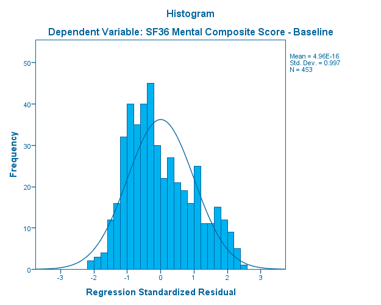

Charts  
Charts - *zresid Normal P-P Plot - December 1, 2018

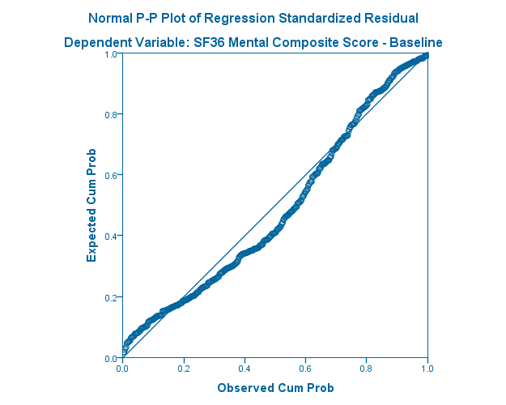

Log  
Log - Log - December 1, 2018

* ============================================.  
* run again using nothomeless  
* and compare the p-values for the age effect  
* ============================================.  
REGRESSION  
/DESCRIPTIVES MEAN STDDEV CORR SIG N  
/MISSING LISTWISE  
/STATISTICS COEFF OUTS CI(95) R ANOVA COLLIN TOL CHANGE ZPP  
/CRITERIA=PIN(.05) POUT(.10)  
/NOORIGIN  
/DEPENDENT mcs  
/METHOD=ENTER nothomeless  
/METHOD=ENTER age  
/METHOD=ENTER age_x_nothomeless  
/RESIDUALS HISTOGRAM(ZRESID) NORMPROB(ZRESID).

Regression  
Regression - Descriptive Statistics - December 1, 2018

Descriptive StatisticsDescriptive Statistics, table, 1 levels of column headers and 1 levels of row headers, table with 4 columns and 6 rows

|  | Mean | Std. Deviation | N |
| --- | --- | --- | --- |
| mcs SF36 Mental Composite Score - Baseline | 31.676678300000000 | 12.839337310000000 | 453 |
| nothomeless | .5386 | .49906 | 453 |
| age Age at baseline (in years) | 35.65 | 7.710 | 453 |
| age_x_nothomeless | 18.8742 | 18.25967 | 453 |

Regression  
Regression - Correlations - December 1, 2018

CorrelationsCorrelations, table, 1 levels of column headers and 2 levels of row headers, table with 6 columns and 14 rows

|  |  | mcs SF36 Mental Composite Score - Baseline | nothomeless | age Age at baseline (in years) | age_x_nothomeless |
| --- | --- | --- | --- | --- | --- |
| Pearson Correlation | mcs SF36 Mental Composite Score - Baseline | 1.000 | .068 | .045 | .053 |
|  | nothomeless | .068 | 1.000 | -.086 | .958 |
|  | age Age at baseline (in years) | .045 | -.086 | 1.000 | .114 |
|  | age_x_nothomeless | .053 | .958 | .114 | 1.000 |
| Sig. (1-tailed) | mcs SF36 Mental Composite Score - Baseline | . | .073 | .172 | .129 |
|  | nothomeless | .073 | . | .034 | .000 |
|  | age Age at baseline (in years) | .172 | .034 | . | .008 |
|  | age_x_nothomeless | .129 | .000 | .008 | . |
| N | mcs SF36 Mental Composite Score - Baseline | 453 | 453 | 453 | 453 |
|  | nothomeless | 453 | 453 | 453 | 453 |
|  | age Age at baseline (in years) | 453 | 453 | 453 | 453 |
|  | age_x_nothomeless | 453 | 453 | 453 | 453 |

Regression  
Regression - Variables Entered/Removed - December 1, 2018

Variables Entered/Removed<sup>a</sup>Variables Entered/Removed, table, 1 levels of column headers and 1 levels of row headers, table with 4 columns and 7 rows

| Model | Variables Entered | Variables Removed | Method |
| --- | --- | --- | --- |
| 1 | nothomeless<sup>b</sup> | . | Enter |
| 2 | age Age at baseline (in years)<sup>b</sup> | . | Enter |
| 3 | age_x_nothomeless<sup>b</sup> | . | Enter |

a. Dependent Variable: mcs SF36 Mental Composite Score - Baseline  
b. All requested variables entered.

Regression  
Regression - Model Summary - December 1, 2018

Model Summary<sup>d</sup>Model Summary, table, 2 levels of column headers and 1 levels of row headers, table with 10 columns and 10 rows

| Model | R | R Square | Adjusted R Square | Std. Error of the Estimate | Change Statistics |  |  |  |  |
| --- | --- | --- | --- | --- | --- | --- | --- | --- | --- |
|  |  |  |  |  | R Square Change | F Change | df1 | df2 | Sig. F Change |
| 1 | .068<sup>a</sup> | .005 | .002 | 12.823589260000000 | .005 | 2.111 | 1 | 451 | .147 |
| 2 | .085<sup>b</sup> | .007 | .003 | 12.821262770000000 | .003 | 1.164 | 1 | 450 | .281 |
| 3 | .136<sup>c</sup> | .018 | .012 | 12.763305860000001 | .011 | 5.096 | 1 | 449 | .024 |

a. Predictors: (Constant), nothomeless  
b. Predictors: (Constant), nothomeless, age Age at baseline (in years)  
c. Predictors: (Constant), nothomeless, age Age at baseline (in years), age_x_nothomeless  
d. Dependent Variable: mcs SF36 Mental Composite Score - Baseline

Regression  
Regression - ANOVA - December 1, 2018

ANOVA<sup>a</sup>ANOVA, table, 1 levels of column headers and 2 levels of row headers, table with 7 columns and 15 rows

| Model |  | Sum of Squares | df | Mean Square | F | Sig. |
| --- | --- | --- | --- | --- | --- | --- |
| 1 | Regression | 347.116 | 1 | 347.116 | 2.111 | .147<sup>b</sup> |
|  | Residual | 74164.443 | 451 | 164.444 |  |  |
|  | Total | 74511.559 | 452 |  |  |  |
| 2 | Regression | 538.409 | 2 | 269.204 | 1.638 | .196<sup>c</sup> |
|  | Residual | 73973.151 | 450 | 164.385 |  |  |
|  | Total | 74511.559 | 452 |  |  |  |
| 3 | Regression | 1368.572 | 3 | 456.191 | 2.800 | .040<sup>d</sup> |
|  | Residual | 73142.987 | 449 | 162.902 |  |  |
|  | Total | 74511.559 | 452 |  |  |  |

a. Dependent Variable: mcs SF36 Mental Composite Score - Baseline  
b. Predictors: (Constant), nothomeless  
c. Predictors: (Constant), nothomeless, age Age at baseline (in years)  
d. Predictors: (Constant), nothomeless, age Age at baseline (in years), age_x_nothomeless

Regression  
Regression - Coefficients - December 1, 2018

Coefficients<sup>a</sup>Coefficients, table, 2 levels of column headers and 2 levels of row headers, table with 14 columns and 13 rows

| Model |  | Unstandardized Coefficients |  | Standardized Coefficients | t | Sig. | 95.0% Confidence Interval for B |  | Correlations |  |  | Collinearity Statistics |  |
| --- | --- | --- | --- | --- | --- | --- | --- | --- | --- | --- | --- | --- | --- |
|  |  | B | Std. Error | Beta |  |  | Lower Bound | Upper Bound | Zero-order | Partial | Part | Tolerance | VIF |
| 1 | (Constant) | 30.731 | .887 |  | 34.645 | .000 | 28.988 | 32.474 |  |  |  |  |  |
|  | nothomeless | 1.756 | 1.209 | .068 | 1.453 | .147 | -.619 | 4.131 | .068 | .068 | .068 | 1.000 | 1.000 |
| 2 | (Constant) | 27.651 | 2.990 |  | 9.249 | .000 | 21.775 | 33.526 |  |  |  |  |  |
|  | nothomeless | 1.868 | 1.213 | .073 | 1.540 | .124 | -.515 | 4.252 | .068 | .072 | .072 | .993 | 1.007 |
|  | age Age at baseline (in years) | .085 | .079 | .051 | 1.079 | .281 | -.070 | .239 | .045 | .051 | .051 | .993 | 1.007 |
| 3 | (Constant) | 21.635 | 3.995 |  | 5.416 | .000 | 13.784 | 29.486 |  |  |  |  |  |
|  | nothomeless | 14.478 | 5.715 | .563 | 2.533 | .012 | 3.247 | 25.708 | .068 | .119 | .118 | .044 | 22.568 |
|  | age Age at baseline (in years) | .250 | .107 | .150 | 2.335 | .020 | .040 | .461 | .045 | .110 | .109 | .528 | 1.893 |
|  | age_x_nothomeless | -.354 | .157 | -.503 | -2.257 | .024 | -.661 | -.046 | .053 | -.106 | -.106 | .044 | 22.695 |

a. Dependent Variable: mcs SF36 Mental Composite Score - Baseline

Regression  
Regression - Excluded Variables - December 1, 2018

Excluded Variables<sup>a</sup>Excluded Variables, table, 2 levels of column headers and 2 levels of row headers, table with 9 columns and 9 rows

| Model |  | Beta In | t | Sig. | Partial Correlation | Collinearity Statistics |  |  |
| --- | --- | --- | --- | --- | --- | --- | --- | --- |
|  |  |  |  |  |  | Tolerance | VIF | Minimum Tolerance |
| 1 | age Age at baseline (in years) | .051<sup>b</sup> | 1.079 | .281 | .051 | .993 | 1.007 | .993 |
|  | age_x_nothomeless | -.147<sup>b</sup> | -.901 | .368 | -.042 | .083 | 12.078 | .083 |
| 2 | age_x_nothomeless | -.503<sup>c</sup> | -2.257 | .024 | -.106 | .044 | 22.695 | .044 |

a. Dependent Variable: mcs SF36 Mental Composite Score - Baseline  
b. Predictors in the Model: (Constant), nothomeless  
c. Predictors in the Model: (Constant), nothomeless, age Age at baseline (in years)

Regression  
Regression - Collinearity Diagnostics - December 1, 2018

Collinearity Diagnostics<sup>a</sup>Collinearity Diagnostics, table, 2 levels of column headers and 2 levels of row headers, table with 8 columns and 13 rows

| Model | Dimension | Eigenvalue | Condition Index | Variance Proportions |  |  |  |
| --- | --- | --- | --- | --- | --- | --- | --- |
|  |  |  |  | (Constant) | nothomeless | age Age at baseline (in years) | age_x_nothomeless |
| 1 | 1 | 1.734 | 1.000 | .13 | .13 |  |  |
|  | 2 | .266 | 2.553 | .87 | .87 |  |  |
| 2 | 1 | 2.618 | 1.000 | .01 | .05 | .01 |  |
|  | 2 | .361 | 2.693 | .01 | .91 | .02 |  |
|  | 3 | .022 | 11.004 | .98 | .04 | .97 |  |
| 3 | 1 | 3.417 | 1.000 | .00 | .00 | .00 | .00 |
|  | 2 | .540 | 2.516 | .01 | .01 | .01 | .01 |
|  | 3 | .036 | 9.747 | .17 | .13 | .17 | .14 |
|  | 4 | .007 | 22.852 | .82 | .86 | .82 | .85 |

a. Dependent Variable: mcs SF36 Mental Composite Score - Baseline

Regression  
Regression - Residuals Statistics - December 1, 2018

Residuals Statistics<sup>a</sup>Residuals Statistics, table, 1 levels of column headers and 1 levels of row headers, table with 6 columns and 7 rows

|  | Minimum | Maximum | Mean | Std. Deviation | N |
| --- | --- | --- | --- | --- | --- |
| Predicted Value | 26.387098310000000 | 36.640998840000000 | 31.676678300000000 | 1.740061426000000 | 453 |
| Residual | -26.801027300000000 | 31.133176800000000 | .000000000000003 | 12.720879240000000 | 453 |
| Std. Predicted Value | -3.040 | 2.853 | .000 | 1.000 | 453 |
| Std. Residual | -2.100 | 2.439 | .000 | .997 | 453 |

a. Dependent Variable: mcs SF36 Mental Composite Score - Baseline

Charts  
Charts - *zresid Histogram - December 1, 2018

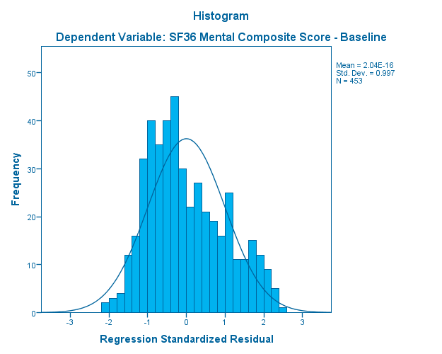

Charts  
Charts - *zresid Normal P-P Plot - December 1, 2018

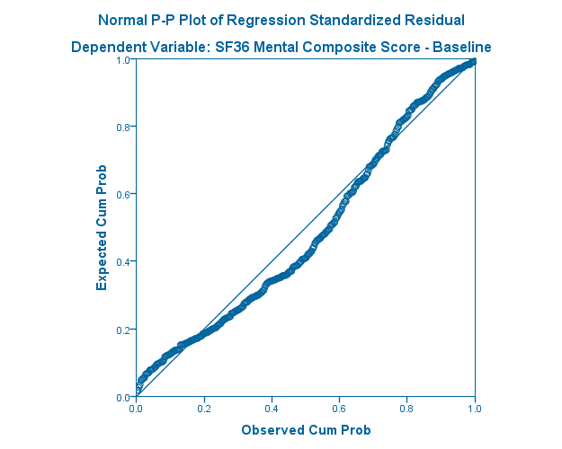

Log  
Log - Log - December 1, 2018

* ============================================.  
* Make a plot of the potential interaction between  
* age and homeless  
* ============================================.  
GRAPH  
/SCATTERPLOT(BIVAR)=mcs WITH age  
/PANEL COLVAR=homeless COLOP=CROSS  
/MISSING=LISTWISE.

Graph  
Graph - Scatter of age mcs - December 1, 2018

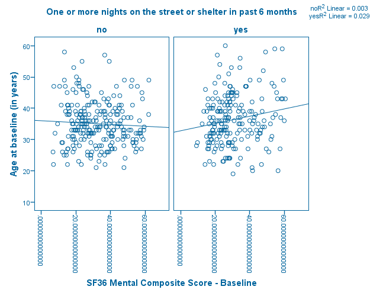

Log  
Log - Log - December 1, 2018

* ============================================.  
* notice that the slope of the lines are different for the  
* homelessness - the slope is slightly negative for  
* nothomeless and more strongly positive for homeless  
* this is WHY the test for the age effect  
* is DIFFERENT in the 2 regression models  
* homeless versus nothomeless  
* ============================================.

[output not shown]

[output not shown]

[output not shown]

[output not shown]

[output not shown]

[output not shown]

[output not shown]

[output not shown]

[output not shown]